# Single Metric Assignment

SOLUTION KEY

Justin Pomeranz

## Problem 1

### Single-site Richness Metrics

For all sub-problems in problem 1, you will only be using the `site1` data object.

#### Problem 1.1

- Calculate the richness (number of taxa) which are in the Order Plecoptera
- Save this result as a data object and print it to the console.

```r
p_rich <- site1 |>
  filter(Order == "Plecoptera") |>
  distinct(site_code, Taxon) |>
  group_by(site_code) |>
  summarize(p_rich = n())
p_rich
```

```
## # A tibble: 1 × 2
##   site_code p_rich
##   <chr>      <int>
## 1 A75CC          7
```

#### Problem 1.2

- Calculate the richness (number of taxa) which are in the Order Trichoptera
- Save this result as a data object
- join this result with the result calculated in 1.1 above and print it to the console.

```r
t_rich <- site1 |>
  filter(Order == "Trichoptera") |>
  distinct(site_code, Taxon) |>
  group_by(site_code) |>
  summarize(t_rich = n())
result1 <- left_join(p_rich, t_rich)
result1
```

```
## # A tibble: 1 × 3
##   site_code p_rich t_rich
##   <chr>      <int>  <int>
## 1 A75CC          7      4
```

#### Problem 1.3

- Calculate the richness (number of taxa) which are in the scraper FFG
- Save this result as a data object
- join this result with the results calculated above and print it to the console.

```r
scrap_rich <- site1 |>
  filter(FFG == "scraper") |>
  distinct(site_code, Taxon) |>
  group_by(site_code) |>
  summarize(scrap_rich = n())
result1 <- left_join(result1, scrap_rich)
result1
```

```
## # A tibble: 1 × 4
##   site_code p_rich t_rich scrap_rich
##   <chr>      <int>  <int>      <int>
## 1 A75CC          7      4          7
```

## Problem 2

### Single-site Metrics with individuals

For all sub-problems in problem 2, you will only be using the `site1` data object.

#### Problem 2.1

- Calculate the percent of individuals which are in the Chironomidae Family
- Save this result as a data object and print it to the console.

```r
c_prop <- site1 |>
  select(site_code, Family, Count) |>
  mutate(tot_n = sum(Count)) |>
  filter(Family == "Chironomidae") |>
  group_by(site_code, tot_n) |>
  summarize(c_n = sum(Count)) |>
  mutate(c_prop = c_n / tot_n) |>
  select(site_code, c_prop)
c_prop
```

```
## # A tibble: 1 × 2
## # Groups:   site_code [1]
##   site_code c_prop
##   <chr>      <dbl>
## 1 A75CC     0.0827
```

#### Problem 2.2

- Calculate the percent of individuals which are in the Scraper FFG
- Save this result as a data object.
- join this result with the result calculated in 2.1 above and print it to the console.

```r
scrap_prop <- site1 |>
  select(site_code, FFG, Count) |>
  mutate(tot_n = sum(Count)) |>
  filter(FFG == "scraper") |>
  group_by(site_code, tot_n) |>
  summarize(sc_n = sum(Count)) |>
  mutate(sc_prop = sc_n / tot_n) |>
  select(site_code, sc_prop)
result1.2 <- left_join(c_prop, scrap_prop)
result1.2
```

```
## # A tibble: 1 × 3
## # Groups:   site_code [1]
##   site_code c_prop sc_prop
##   <chr>      <dbl>   <dbl>
## 1 A75CC     0.0827   0.260
```

## Problem 3

### Multiple-site Metrics

All sub-problems in problem 3 will work with the `site1` and `site2` data objects which have been combined using `bind_rows()`.

```r
two_sites <- bind_rows(site1, site2)
```

#### Problem 3.1

- Calculate the EPT richness for your two sites
- Save this result as a new data object and print it to the screen

```r
ept_rich <- two_sites %>%
  filter(Order == "Ephemeroptera" |
           Order == "Plecoptera" |
           Order == "Trichoptera") |>
  distinct(site_code, Taxon) |>
  group_by(site_code) |>
  summarize(EPT_rich = n())
ept_rich
```

```
## # A tibble: 2 × 2
##   site_code EPT_rich
##   <chr>        <int>
## 1 A72              6
## 2 A75CC           19
```

#### Problem 3.2

- Calculate the per cent of individuals which are in the shredder FFG.
- Save this result as a new data object
- Join it to your result from 3.1 and print it to the screen

```r
shred_i <- two_sites %>%
  select(site_code, FFG, Count) |>
  mutate(tot_n = sum(Count)) |>
  filter(FFG == "shredder") |>
  group_by(site_code, tot_n) |>
  summarize(shred_n = sum(Count)) |>
  mutate(shred_percent_ind = shred_n / tot_n) |>
  select(site_code, shred_percent_ind)
a3.2 <- left_join(ept_rich, shred_i)
a3.2
```

```
## # A tibble: 2 × 3
##   site_code EPT_rich shred_percent_ind
##   <chr>        <int>             <dbl>
## 1 A72              6             0.121
## 2 A75CC           19             0.111
```

#### Problem 3.3

- Calculate the Shannon Diversity for these two sites.
- Save this result as a new data object
- Join it to your previous results from problem 3 and print it to the screen

```r
shannon <- two_sites |>
  select(site_code, Taxon, Count) |>
  mutate(tot_n = sum(Count),
         pi = Count / tot_n,
         ln_pi = log(pi),
         pi_ln_pi = pi*ln_pi) |>
  group_by(site_code) |>
  summarize(H = -sum(pi_ln_pi))
a3.3 <- left_join(a3.2, shannon)
a3.3
```

```
## # A tibble: 2 × 4
##   site_code EPT_rich shred_percent_ind     H
##   <chr>        <int>             <dbl> <dbl>
## 1 A72              6             0.121 0.525
## 2 A75CC           19             0.111 2.60
```

#### Problem 3.4

- Calculate the percent of individuals which are in the Chironomidae Family
- Save this result as a new data object
- Join it to your previous results from problem 3 and print it to the screen

```r
c_ind <- two_sites|>
  select(site_code, Family, Count) |>
  mutate(tot_n = sum(Count)) |>
  filter(Family == "Chironomidae") |>
  group_by(site_code, tot_n) |>
  summarize(c_n = sum(Count)) |>
  mutate(c_percent_ind = c_n / tot_n) |>
  select(site_code, c_percent_ind)
a3.4 <- left_join(a3.3, c_ind)
a3.4
```

```
## # A tibble: 2 × 5
##   site_code EPT_rich shred_percent_ind     H c_percent_ind
##   <chr>        <int>             <dbl> <dbl>         <dbl>
## 1 A72              6             0.121 0.525        0.0182
## 2 A75CC           19             0.111 2.60         0.0678
```

#### Problem 3.5 Challenge (optional)

This sub-problem is optional. Problem number 4 is not optional

- Calculate the percent of individuals which are in the EPT orders but remove all individuals in the Baetidae Family
- Save this result as a new data object
- Join it to your previous results from problem 3 and print it to the screen

```r
ept_no_b <- two_sites |>
  select(site_code, Order, Family, Count) |>
  mutate(tot_n = sum(Count)) |>
  filter(Order == "Ephemeroptera" |
           Order == "Plecoptera" |
           Order == "Trichoptera",
         Family != "Baetidae") |>
  group_by(site_code, tot_n) |>
  summarize(ept_n = sum(Count)) |>
  mutate(ept_no_b_percent_ind = ept_n / tot_n) |>
  select(site_code, ept_no_b_percent_ind)
a3.5 <- left_join(a3.4, ept_no_b)
a3.5
```

```
## # A tibble: 2 × 6
##   site_code EPT_rich shred_percent_ind     H c_percent_ind ept_no_b_percent_ind
##   <chr>        <int>             <dbl> <dbl>         <dbl>                <dbl>
## 1 A72              6             0.121 0.525        0.0182                0.157
## 2 A75CC           19             0.111 2.60         0.0678                0.526
```

## Problem 4

### Plots

- All sub-problems in problem 4 will be working with the combined results from problem 3. i.e., the results from the two sites.
- All plots made in part 4 need to have the following:
  - A short, informative title.
  - x- and y-axis labels
  - Fill colors need to be based on the impact category variable.
  - The color palettes that you use are up to you
- Before you can plot, you will need to join the `site_info` to your results using the `left_join()` function.

```r
results <- left_join(a3.5, site_info)
```

#### Problem 4.1

- Make a bar plot of the EPT richness results

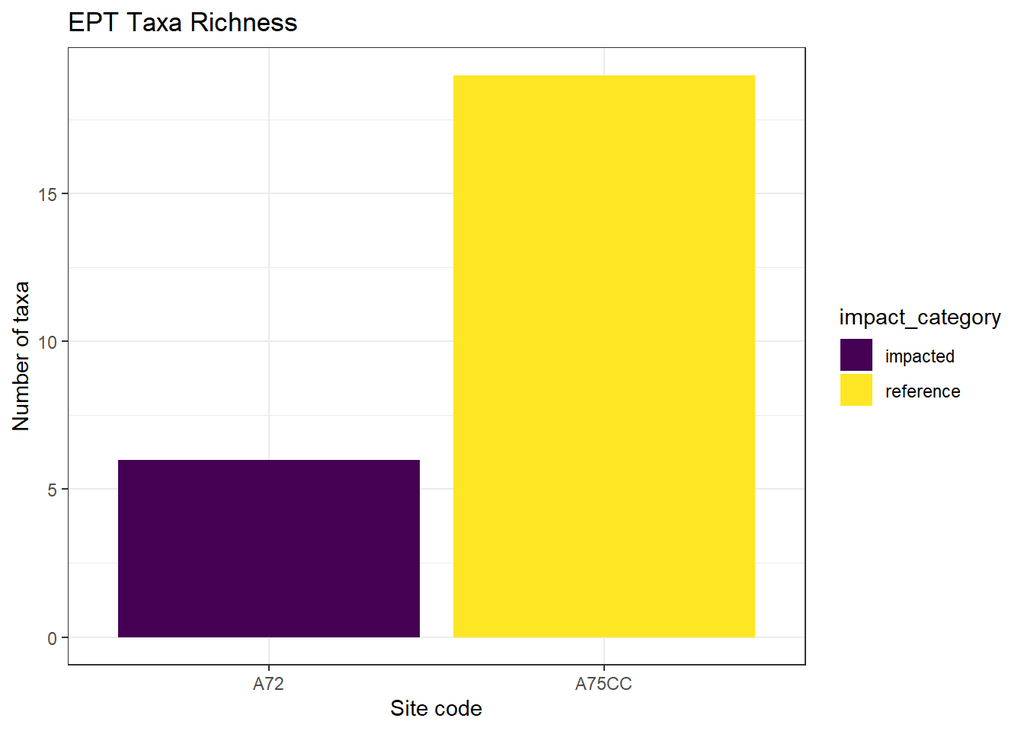

```r
ggplot(results,
       aes(x = site_code,
           y = EPT_rich,
           fill = impact_category)) +
  geom_bar(stat = "identity") +
  labs(title = "EPT Taxa Richness",
       x = "Site code",
       y = "Number of taxa") +
  scale_fill_viridis_d() +
  theme_bw()
```

#### Problem 4.2

- Make a bar plot of the percent of individuals in the shredder FFG

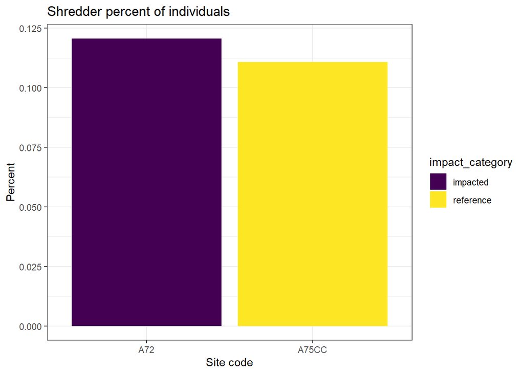

```r
ggplot(results,
       aes(x = site_code,
           y = shred_percent_ind,
           fill = impact_category)) +
  geom_bar(stat = "identity") +
  labs(title = "Shredder percent of individuals",
       x = "Site code",
       y = "Percent") +
  scale_fill_viridis_d() +
  theme_bw()
```

#### Problem 4.3

- Make a bar plot of the Shannon Diversity results

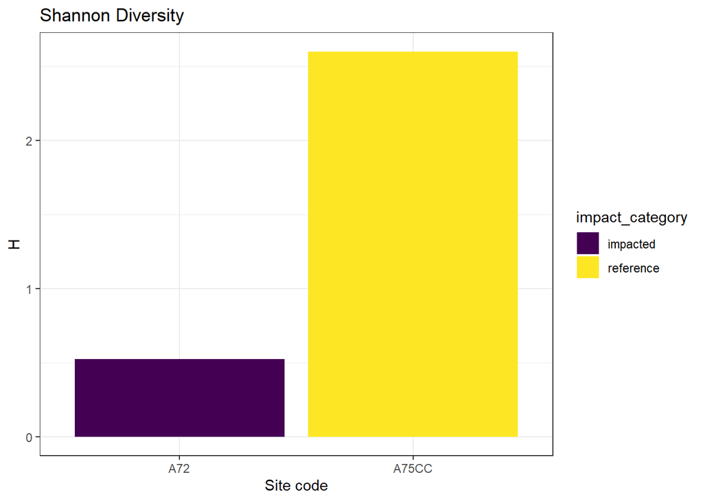

```r
ggplot(results,
       aes(x = site_code,
           y = H,
           fill = impact_category)) +
  geom_bar(stat = "identity") +
  labs(title = "Shannon Diversity",
       x = "Site code",
       y = "H") +
  scale_fill_viridis_d() +
  theme_bw()
```

#### Problem 4.4

- Make a bar plot of the percent of individuals in the Chironomidae Family results

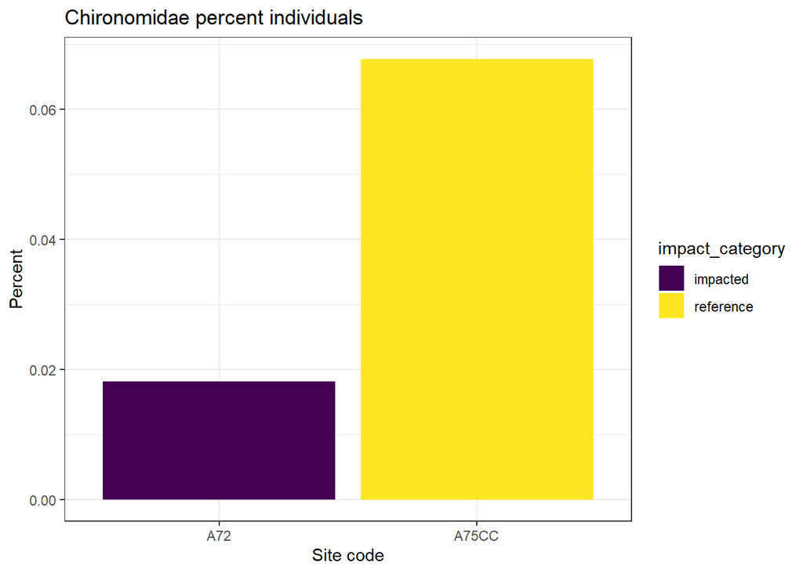

```r
ggplot(results,
       aes(x = site_code,
           y = c_percent_ind,
           fill = impact_category)) +
  geom_bar(stat = "identity") +
  labs(title = "Chironomidae percent individuals",
       x = "Site code",
       y = "Percent") +
  scale_fill_viridis_d() +
  theme_bw()
```

#### Problem 4.5 (Optional, if you did problem 3.5)

- Make a bar plot of the percent of individuals in EPT orders without individuals which are in Baetidae results

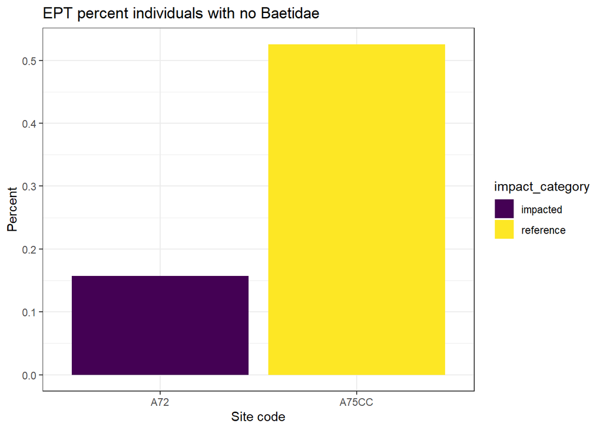

```r
ggplot(results,
       aes(x = site_code,
           y = ept_no_b_percent_ind,
           fill = impact_category)) +
  geom_bar(stat = "identity") +
  labs(title = "EPT percent individuals with no Baetidae",
       x = "Site code",
       y = "Percent") +
  scale_fill_viridis_d() +
  theme_bw()
```

## This concludes this R-assignment